# p8105_hw3_mb5357

Maria Beg

2025-10-07

## QUESTION 1

**Description of the Instacart Dataset**

The `instacart` dataset is a line-item level table of grocery orders from Instacart, where each row represents a single product in a single order.

Key variables include `order_id`, `product_id`, `user_id`, `add_to_cart_order` (position of the item in the cart), `reordered` (0/1), `order_dow` (day of week), and `order_hour_of_day`. Orders are categorized by `eval_set`, and user purchase history is captured via `order_number`.

The dataset can be joined with metadata tables such as `products`, `aisles`, and `departments` using `product_id`. In this version of the dataset, all observations come from the “train” evaluation set.

For example, user 112108 placed their 4th order on day 4 of the week at 10 AM. This order (order ID 1) contained eight products, including “Bulgarian Yogurt”, “Organic Celery Hearts”, and “Organic Hass Avocado”. Each product appears in a separate row, with variables indicating the order in which the item was added to the cart (e.g., “Bulgarian Yogurt” was first), whether it was reordered (1 = yes, 0 = no), and what aisle and department it belongs to (e.g., “fresh fruits” in the “produce” department).

**Number of aisles and most ordered aisles**

```r
aisle_counts <- instacart |>
  count(aisle,
        name = "orders", sort = TRUE)

total_aisles <- nrow(aisle_counts)

aisle_counts |>
  mutate(total_aisles = total_aisles) |>
  relocate(total_aisles, .before = aisle)
```

```
## # A tibble: 134 × 3
##    total_aisles aisle                         orders
##           <int> <chr>                          <int>
##  1          134 fresh vegetables              150609
##  2          134 fresh fruits                  150473
##  3          134 packaged vegetables fruits     78493
##  4          134 yogurt                         55240
##  5          134 packaged cheese                41699
##  6          134 water seltzer sparkling water  36617
##  7          134 milk                           32644
##  8          134 chips pretzels                 31269
##  9          134 soy lactosefree                26240
## 10          134 bread                          23635
## # ℹ 124 more rows
```

*There are 134 aisles in total. Fresh vegetables and fresh fruits aisles are the most items ordered from.*

**Plot of items ordered per aisle**

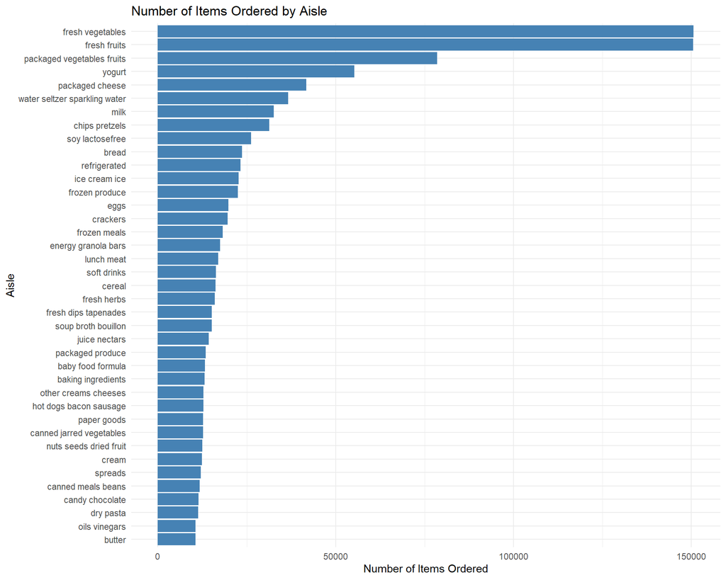

```r
instacart |>
  count(
    aisle, sort = TRUE) |>

  filter(
    n > 10000) |>

  mutate(
    aisle = reorder(aisle, n)) |>

  ggplot(aes(x = n, y = aisle)) +
  geom_col(fill = "steelblue") +
  labs(
    title = "Number of Items Ordered by Aisle",
    x = "Number of Items Ordered",
    y = "Aisle"
  ) +
  theme_minimal()
```

**Top 3 items in selected aisles**

```r
top_items_table <- instacart |>
  filter(aisle == "baking ingredients" |
         aisle == "dog food care" |
         aisle == "packaged vegetables fruits") |>

  count(
    aisle,
    product_name,
    name = "orders") |>

  group_by(aisle) |>
  slice_max(orders, n = 3) |>
  ungroup()

top_items_table |>
  kable()
```

| aisle | product_name | orders |
| --- | --- | --- |
| baking ingredients | Light Brown Sugar | 499 |
| baking ingredients | Pure Baking Soda | 387 |
| baking ingredients | Cane Sugar | 336 |
| dog food care | Snack Sticks Chicken & Rice Recipe Dog Treats | 30 |
| dog food care | Organix Chicken & Brown Rice Recipe | 28 |
| dog food care | Small Dog Biscuits | 26 |
| packaged vegetables fruits | Organic Baby Spinach | 9784 |
| packaged vegetables fruits | Organic Raspberries | 5546 |
| packaged vegetables fruits | Organic Blueberries | 4966 |

**Mean order hour for “Pink Lady Apples” and “Coffee Ice Cream” by day of week**

```r
day_names <- c("Sun", "Mon", "Tue", "Wed", "Thu", "Fri", "Sat")

mean_hour_table <- instacart |>
  filter(product_name == "Pink Lady Apples" |
         product_name == "Coffee Ice Cream") |>

   mutate(day_name = factor(day_names[order_dow + 1],
                             levels = day_names)) |>

   group_by(product_name,
           day_name) |>

  summarize(mean_order_hour = round(mean(order_hour_of_day), 1),
              .groups = "drop") |>

   pivot_wider(
    names_from = day_name,
    values_from = mean_order_hour
    )

mean_hour_table |>
  kable()
```

| product_name | Sun | Mon | Tue | Wed | Thu | Fri | Sat |
| --- | --- | --- | --- | --- | --- | --- | --- |
| Coffee Ice Cream | 13.8 | 14.3 | 15.4 | 15.3 | 15.2 | 12.3 | 13.8 |
| Pink Lady Apples | 13.4 | 11.4 | 11.7 | 14.2 | 11.6 | 12.8 | 11.9 |

## Question 2

**Import and Clean the datasets**

```r
zipcodes_df <- read_csv("Zip Codes.csv", show_col_types = FALSE) |>
  janitor::clean_names() |>

  mutate(
     county = case_when(
      county == "New York" ~ "Manhattan",
      county == "Kings"    ~ "Brooklyn",
      county == "Richmond" ~ "Staten Island",
      TRUE ~ county
    )
  ) |>

   distinct(zip_code, .keep_all = TRUE) |>
  select(county, zip_code)


zori_df <- read_csv("Zip_zori_uc_sfrcondomfr_sm_month_NYC.csv",
                    show_col_types = FALSE) |>
  janitor::clean_names()|>

  pivot_longer(
    cols = starts_with("x20"),
    names_to = "date",
    values_to = "zori"
  ) |>

   mutate(
    date = lubridate::ymd(str_remove(date, "x")),
    year = year(date),
    month = month(date)
  ) |>

  select(region_name, year, month, zori)



combined_df <- left_join(zori_df, zipcodes_df,
                         by = c("region_name" = "zip_code"))

combined_df <- combined_df |>
    filter(!is.na(zori)) |>

  rename(zip_code = region_name,
         borough = county) |>

   mutate(month = month.name[month])
```

**ZIP Codes Observation**

```r
zip_counts <- combined_df |>
  group_by(zip_code) |>
  summarize(n_months = n()) |>
  ungroup()

zip_counts |>
  summarize(
    full_coverage = sum(n_months == 116),
    very_sparse = sum(n_months < 10)
  )
```

```
## # A tibble: 1 × 2
##   full_coverage very_sparse
##           <int>       <int>
## 1            48          26
```

A total of 48 ZIP codes have complete data, appearing in all 116 months from January 2015 to August 2024. Conversely, 26 ZIP codes are observed fewer than 10 times during this period. ZIP codes with full coverage likely represent stable residential areas with consistent rental activity and reliable data reporting. Those with sparse observations may reflect areas with limited rental market activity, newer ZIP codes, or data gaps.

**Average rental price per borough and year**

```r
borough_year_table <- combined_df |>
  group_by(borough,
           year) |>

   summarize(avg_rent = mean(zori, na.rm = TRUE),
            .groups = "drop") |>

   arrange(borough, year) |>

   pivot_wider(
    names_from = borough,
    values_from = avg_rent
  )

borough_year_table |>
  kable()
```

| year | Bronx | Brooklyn | Manhattan | Queens | Staten Island |
| --- | --- | --- | --- | --- | --- |
| 2015 | 1759.595 | 2492.928 | 3022.042 | 2214.707 | NA |
| 2016 | 1520.194 | 2520.357 | 3038.818 | 2271.955 | NA |
| 2017 | 1543.599 | 2545.828 | 3133.848 | 2263.303 | NA |
| 2018 | 1639.430 | 2547.291 | 3183.703 | 2291.918 | NA |
| 2019 | 1705.589 | 2630.504 | 3310.408 | 2387.816 | NA |
| 2020 | 1811.443 | 2555.051 | 3106.517 | 2315.632 | 1977.608 |
| 2021 | 1857.777 | 2549.890 | 3136.632 | 2210.787 | 2045.430 |
| 2022 | 2054.267 | 2868.199 | 3778.375 | 2406.038 | 2147.436 |
| 2023 | 2285.459 | 3015.184 | 3932.610 | 2561.615 | 2332.934 |
| 2024 | 2496.896 | 3125.657 | 4078.440 | 2693.584 | 2536.442 |

**NYC rental prices within ZIP codes**

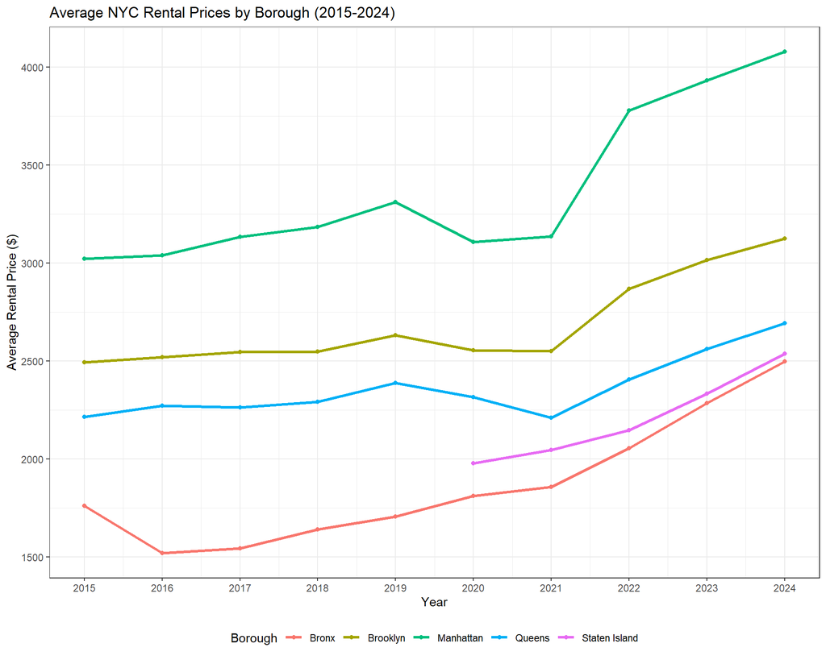

```r
library(ggplot2)

borough_year_avg <- combined_df |>
  group_by(year,
           borough) |>
  summarize(avg_rent = mean(zori, na.rm = TRUE),
            .groups = "drop")


plot_1 <- ggplot(borough_year_avg,
                 aes(x = year,
                     y = avg_rent,
                     color = borough)) +

  geom_line(linewidth = 1.2) +
  geom_point() +
  scale_x_continuous(breaks = seq(2015, 2024, 1)) +
  labs(
    title = "Average NYC Rental Prices by Borough (2015-2024)",
    x = "Year",
    y = "Average Rental Price ($)",
    color = "Borough"
  ) +
  theme_bw() +
  theme(legend.position = "bottom")


plot_1
```

**ZIP-Code level Rent**

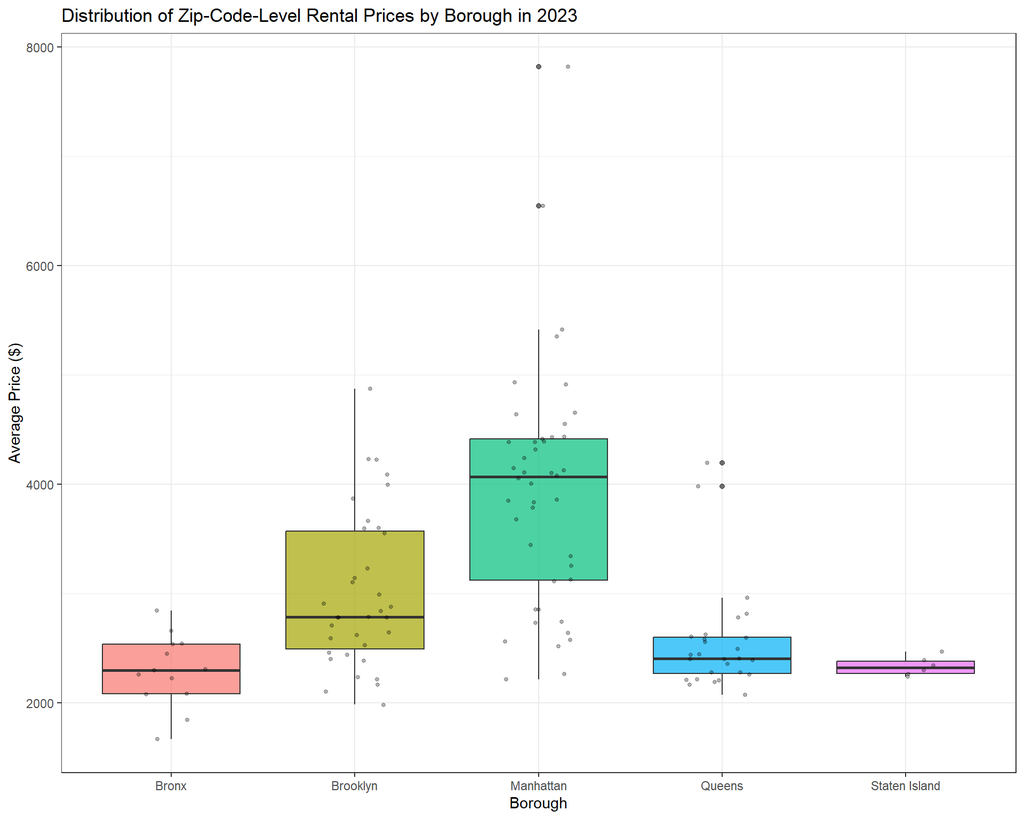

```r
zip_month_2023 <- combined_df |>
  filter(year == 2023) |>
  group_by(borough,
           zip_code,
           month) |>
  summarize(avg_rent = mean(zori, na.rm = TRUE),
            .groups = "drop")


zip_avg_2023 <- zip_month_2023 |>
  group_by(borough,
           zip_code) |>
  summarize(avg_rent_2023 = mean(avg_rent, na.rm = TRUE),
            .groups = "drop")


plot_2 <- ggplot(zip_avg_2023,
          aes(x = borough,
              y = avg_rent_2023,
              fill = borough)) +

  geom_boxplot(alpha = 0.7) +
  geom_jitter(width = 0.2,
              alpha = 0.3,
              size = 1) +

  scale_y_continuous() +
  labs(
    title = "Distribution of Zip-Code-Level Rental Prices by Borough in 2023",
    x = "Borough",
    y = "Average Price ($)",
    fill = "Borough"
  ) +
  theme_bw() +
  theme(legend.position = "none")


plot_2
```

The boxplot reveals clear differences in ZIP-level average rents across boroughs in 2023. Manhattan has the highest median rent and the widest range, with a long upper tail reflecting some very high-rent ZIPs. Brooklyn follows with relatively high median rents and substantial variability. Queens, the Bronx, and Staten Island have lower and more similar median rents, with Staten Island showing the tightest range. Some outliers with very high rents are visible, likely due to a small number of luxury listings or data irregularities.

**Combined Plots**

```r
library(patchwork)

combined_plot <- plot_1 / plot_2

ggsave("results/combined_plot.png", combined_plot, width = 10, height = 8)
```

## Question 3

**Import and Clean the datasets**

```r
accel_df <- read_csv("nhanes_accel.csv", show_col_types = FALSE) |>
  pivot_longer(
    cols = starts_with("min"),
    names_to = "minute",
    values_to = "mims"
  ) |>
  mutate(minute = as.integer(str_remove(minute, "min")))



sex_levels <- c("male", "female")
education_levels <- c("Less than high school", "High school equivalent", "More than high school")

covar_df <- read_csv("nhanes_covar.csv", skip = 4, show_col_types = FALSE) |>
  mutate(
    sex = case_when(
      sex == 1 ~ sex_levels[1],
      sex == 2 ~ sex_levels[2],
      TRUE ~ NA_character_
    ),

    education = case_when(
      education == 1 ~ education_levels[1],
      education == 2 ~ education_levels[2],
      education == 3 ~ education_levels[3],
      TRUE ~ NA_character_
    )

  ) |>
  filter(age >= 21) |>

  mutate(
    sex = factor(sex, levels = sex_levels),
    education = factor(education, levels = education_levels, ordered = TRUE)
  )


nhanes_df <- left_join(accel_df, covar_df,
                       by = "SEQN") |>
             drop_na(sex, age, education)
```

**Number of men and women in each education category**

```r
sex_dist_table <- covar_df |>
  count(education, sex) |>

  pivot_wider(
    names_from = sex,
    values_from = n,
    values_fill = 0
  )

sex_dist_table |>
  kable()
```

| education | male | female |
| --- | --- | --- |
| Less than high school | 28 | 29 |
| High school equivalent | 36 | 23 |
| More than high school | 56 | 59 |

The table shows a fairly even gender distribution across education levels. Most participants have more than a high school education, with women slightly outnumbering men in that category. Men are more represented in the high school equivalent group, while the lowest education level is nearly balanced. Overall, the sample leans toward higher educational attainment for both sexes.

**Visualization of Age Distributions**

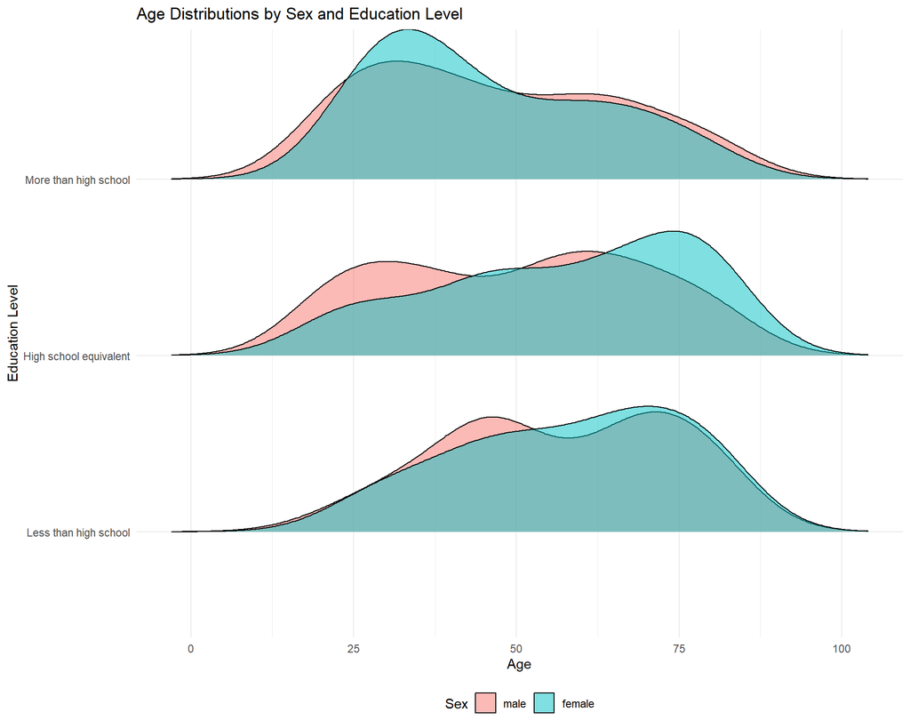

```r
library(ggridges)

ggplot(covar_df, aes(x = age,
                     y = education,
                     fill = sex)) +

  geom_density_ridges(alpha = 0.5,
                      scale = .85) +
  labs(
    title = "Age Distributions by Sex and Education Level",
    x = "Age",
    y = "Education Level",
    fill = "Sex"
  ) +
  theme_minimal() +
    theme(legend.position = "bottom")
```

**Aggregate total activity per participant**

```r
total_activity_df <- nhanes_df |>
  group_by(SEQN, sex, age, education) |>

  summarise(total_mims = sum(mims, na.rm = TRUE),
            .groups = "drop")
```

**Plot total activity vs age by sex and education**

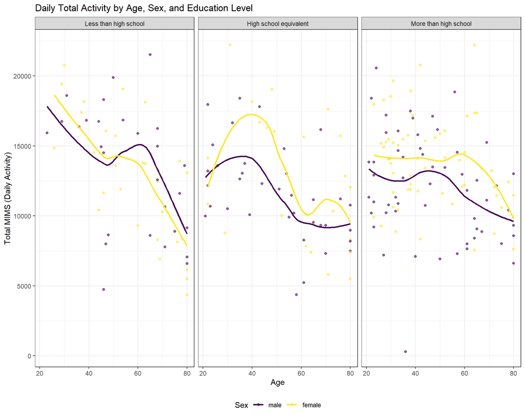

```r
ggplot(total_activity_df,
       aes(x = age,
           y = total_mims,
           color = sex)) +
  geom_point(alpha = 0.6) +
  geom_smooth(se = FALSE) +

  facet_grid(~ education) +
  viridis::scale_color_viridis(discrete = TRUE) +

  labs(
    title = "Daily Total Activity by Age, Sex, and Education Level",
    x = "Age",
    y = "Total MIMS (Daily Activity)",
    color = "Sex"
  ) +
  theme_bw() +
    theme(legend.position = "bottom")
```

**Three-panel Plot**

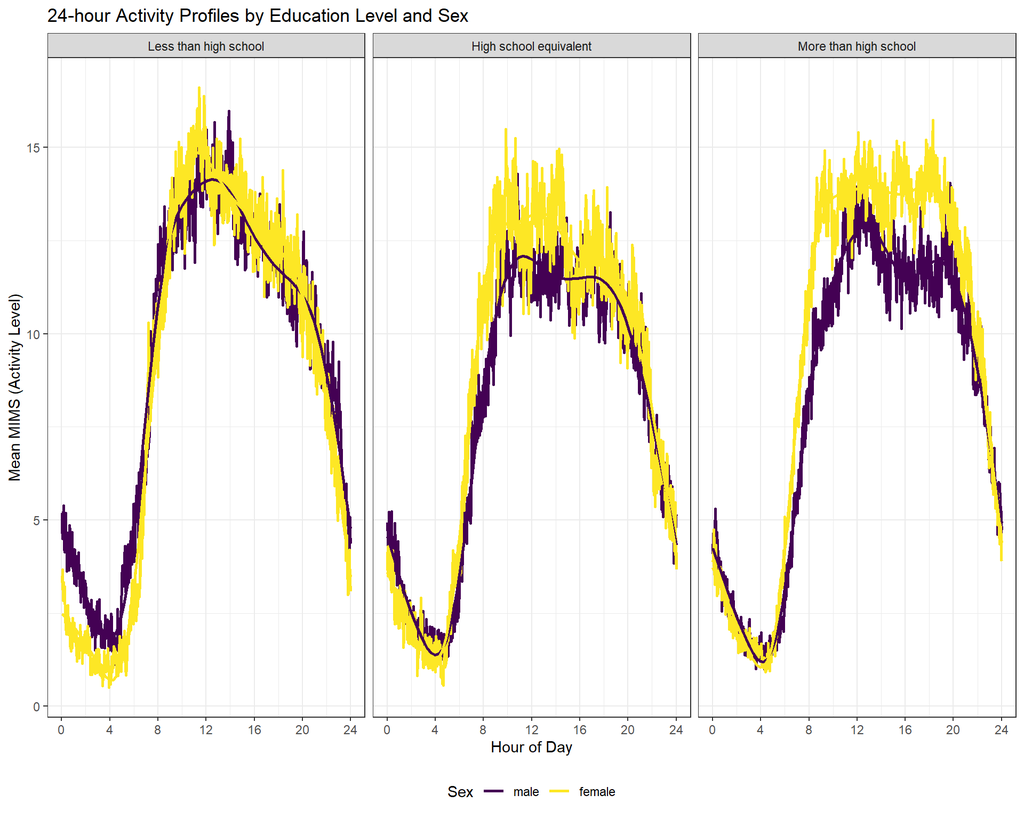

```r
nhanes_df <- nhanes_df |>
  mutate(hour = minute / 60)


ggplot(nhanes_df, aes(x = hour,
                      y = mims,
                      color = sex,
                      group = sex)) +

 stat_summary(
    fun = mean,
    geom = "line",
    linewidth = 1,
  ) +

  geom_smooth(
    se = FALSE) +

  facet_grid(~ education) +
  viridis::scale_color_viridis(discrete = TRUE) +

  scale_x_continuous(
   breaks = seq(0, 24, by = 4)) +

   labs(
    title = "24-hour Activity Profiles by Education Level and Sex",
    x = "Hour of Day",
    y = "Mean MIMS (Activity Level)",
    color = "Sex"
  ) +
  theme_bw() +
  theme(legend.position = "bottom")
```